# Compared to What?

Module 2 · Day 1, Session 1: Know the Language First

3ie

## What this session gives you

By the end of this session you will be able to:

- Ask the one question every impact evaluation result has to answer: **compared to what?**
- Explain, in plain language, the terms you will hear all week: mean, comparison group, treatment effect, coefficient, p-value, confidence interval
- Recognise when “statistically significant” is being used to mean something it does not
- Use AI to explain an unfamiliar term, and know what to check when it does

The goal of these sessions is to provide you with insight on how we get to impact evaluation results, to read and interpret those results with confidence, and to know what critical questions to ask.

# 1 · Compared to what? 15 min

## The Al Falah Road Safety Campaign

A national government runs a one-year awareness campaign: billboards, TV spots, and school talks promoting seatbelt use and safe speeds.

At the end of the year, someone has to decide: did it work, and should it run again?

*Illustrative example, not a real Abu Dhabi case study.*

Ran

One year, nationwide

Delivered

Billboards, TV spots, school talks

Outcome

Traffic fatalities

The question

Did the campaign save lives?

## The headline number

-30%

Traffic fatalities, year on year

420Deaths, year before

294Deaths, year after

-126Fewer deaths

## Show of hands

Based on this evidence, did the campaign save lives?

## Before we celebrate, what else happened that year?

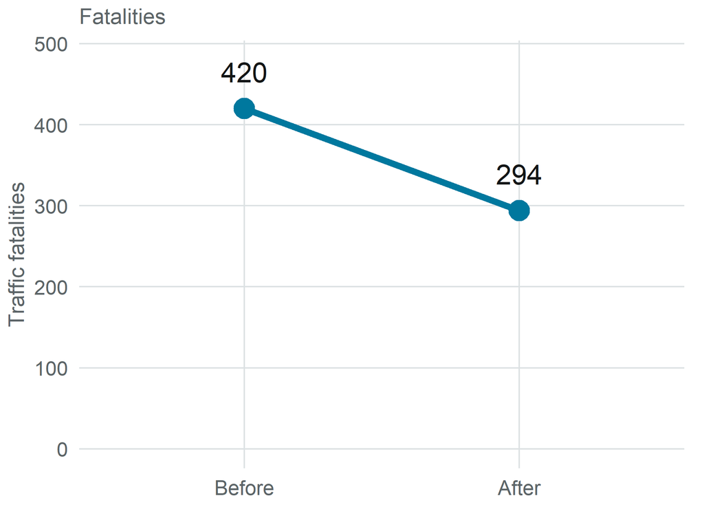

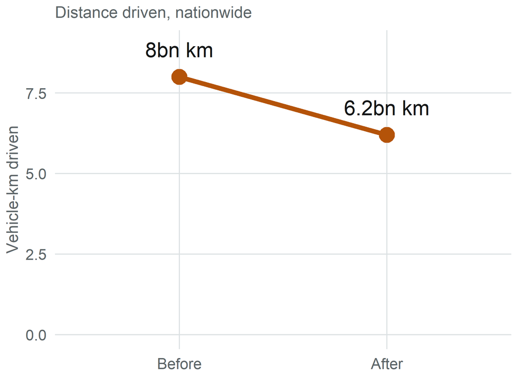

Fuel prices rose sharply that year. People simply drove less: a 22% drop in distance driven, nationwide, for reasons that have nothing to do with the campaign.

## What actually happened to the death rate

-10%

Fatalities per billion km driven

52Rate before

47Rate after

Once you account for how much less people drove, the campaign’s apparent effect mostly disappears. The 30% headline was mostly the fuel price, not the campaign.

## Compared to what?

“Compared to what?”

Every evaluation result is a comparison. A before-and-after number compares the programme to *the past*, not to what would have happened anyway. If you do not know what a number is being compared to, you do not yet know what it means.

# 2 · Test yourselves 10 min

## The BrightStart After-School Tutoring Program

A tutoring programme runs in a set of schools for two years. Afterwards, Grade 6 maths pass rates in those schools are compared to where they started.

*Illustrative example, not a real Abu Dhabi case study.*

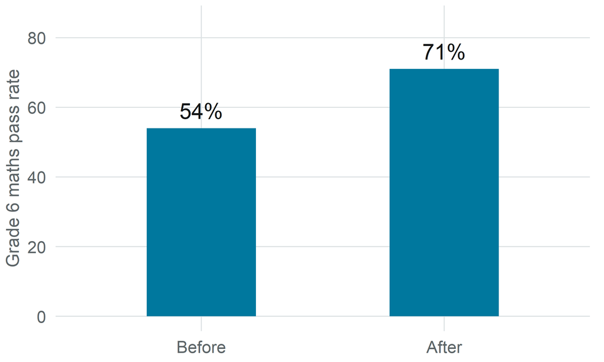

## `[MENTI PLACEHOLDER]` Did it work?

Live poll: **Based on what you see, did BrightStart cause the improvement?**

Yes · No · Can’t tell without more information

Results display live as a bar chart. Do not reveal the national comparison yet, let the room commit first.

## `[MENTI PLACEHOLDER]` What’s missing?

Open text, rendered as a live word cloud: **In one phrase, what’s missing from this evidence?**

## Meanwhile, across the country

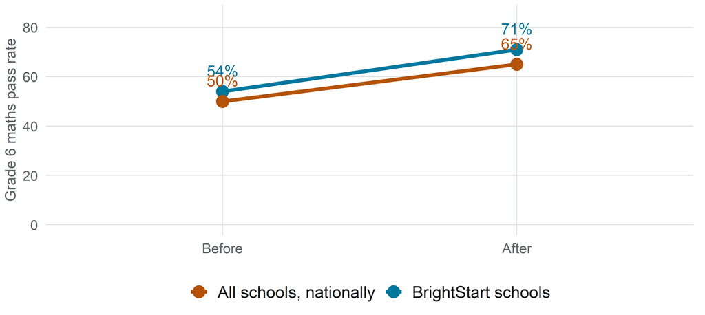

An unrelated national curriculum reform landed the same two years. Pass rates rose everywhere, not just in BrightStart schools.

## Revisit your answer

Now that you have seen the comparison: would you change your Menti answer? What would you want to know before trusting *any* before-and-after claim?

BrightStart schools gained 17 points. Schools nationally gained 15 points with no programme at all. The gain BrightStart can actually claim is closer to 2 points, not 17.

# 3 · Learn the language 15 min

## Mean (average)

**Plain language:** add everything up, divide by how many there are.

A “mean cost of 1,449 AED” is not any single business’s cost. It is where the whole group sits on average, and it can hide a lot of spread underneath it.

**Example:** the 71% pass rate on BrightStart’s chart is a mean: the average across every school in the programme, not any one school’s result.

## Comparison group

**Plain language:** the group we hold up next to the group that got the programme, ideally as similar as possible in every way except the programme itself.

This is the formal name for the thing missing from both stories you just saw. Without it, “compared to what” has no answer.

**Example:** “all schools, nationally” was BrightStart’s comparison group: schools with no tutoring, used to judge what would have happened anyway.

## Treatment effect

**Plain language:** the honest difference the programme made, once it has been compared to the right group.

Not the change over time. Not the gap between groups at the end. The part of the change that the comparison group did not also experience.

**Example:** BrightStart’s raw gain was 17 points. Its treatment effect, the part it can actually claim, is closer to 2 points, once the comparison group’s own 15-point gain is subtracted out.

## Coefficient

**Plain language:** a number a statistical model reports to describe the size of a relationship. In an evaluation table, the coefficient on the programme variable is often the treatment effect itself.

You will see coefficients in a table most days this week. The skill is knowing which one answers your question.

**Example:** that same 2-point effect is what you would find as the coefficient on “Program” in a regression table, next slide.

## A regression table, annotated

An evaluator runs a regression instead of doing the subtraction by hand, because it can hold other things constant at the same time.

| Variable | Coefficient | Std. error | p-value | 95% CI |
| --- | --- | --- | --- | --- |
| (Intercept) | 40.50 | 3.20 | <0.001 | [34.20, 46.80] |
| Program (BrightStart = 1) | 2.10 | 0.90 | 0.021 | [0.30, 3.90] |
| Baseline pass rate (prior year) | 0.58 | 0.04 | <0.001 | [0.50, 0.66] |
| Class size (students) | -0.32 | 0.14 | 0.024 | [-0.59, -0.05] |
| Teacher experience (years) | 0.15 | 0.08 | 0.06 | [-0.01, 0.31] |

N = 240 schools. Outcome: Grade 6 maths pass rate.

## The same table, in plain language

**Coefficient (highlighted row):** the treatment effect. 2.1 points, close to the 2 we found by hand; regression refines it slightly by also holding the covariates below constant.

**Covariates:** the other rows (baseline pass rate, class size, teacher experience). Other measured differences between schools, included so they are not confused with the programme’s own effect.

**Std. error and 95% CI:** how much this estimate might move around if you ran the study again. A range that crosses zero (teacher experience) means “we cannot rule out no effect at all.”

**p-value:** how surprising each coefficient would be if its true effect were zero.

**N:** the sample size, 240 schools. Keep this number in mind, it matters a great deal in Section 5.

## Four terms so far

Mean

The average of a group

Comparison group

Who we hold the programme group up against

Treatment effect

The honest difference, once compared properly

Coefficient

The number in the table that reports it

# 4 · Put AI to work 10 min

## AI Prompt Cards

Each group takes one term card. Paste its prompt into your AI tool of choice, read the answer together, and mark anything you think it got wrong or overstated.

**Prompt:** “Explain what a treatment effect is in an evaluation.”

**AI:** “The treatment effect is the number that shows how much the programme changed the outcome. It tells you the programme caused all of the change you observed. For example, if costs fell by 500 AED after the programme, the treatment effect is 500 AED.”

## Debrief

What did AI get right? What did it skate over?

The flagged sentence quietly drops the comparison group. AI answered as if this were a before-and-after number, the exact trap from Section 1.

# 5 · The most misunderstood term 15 min

## p-value

**Plain language:** roughly, how surprising this result would be if the programme had truly done nothing at all. A small p-value means “this would be a strange coincidence if there were no effect.”

A p-value tells you about confidence that an effect is not exactly zero. It tells you nothing about whether the effect is big enough to matter.

## Confidence interval

**Plain language:** a range of plausible values for the true effect, not one precise number. A wider range means less certainty, not a bigger effect.

When someone reports “-816 AED, 95% CI [-1,120, -512]”, the honest reading is: probably somewhere in that range, not exactly -816.

## `.warn` Two traps evaluators fall into

**“Statistically significant” does not mean “big” or “important.”** It means we are confident the effect is not exactly zero. A huge sample can make a tiny, meaningless effect “significant.” A small sample can make a large, real effect look “not significant.”

**A study that finds nothing may simply have been too small to see anything.** Absence of evidence is not evidence of absence. Always ask how many people or businesses the study had before believing a “no effect” result.

# 6 · Quick check 5 min

## `[MENTI PLACEHOLDER]` True or false?

1. A statistically significant result is always a big result.
2. A small study that finds no effect proves the programme did not work.
3. A comparison group should look as similar as possible to the group that got the programme.
4. A wide confidence interval means we are very sure of the exact effect.

Live Menti quiz, answers revealed one at a time. (1) False (2) False (3) True (4) False

# 7 · Bring it together 15 min

## Terms Bingo

Each of you has a bingo card with today’s terms scattered across the grid. As excerpts from real evaluation findings are read aloud, mark off any term you hear used. First full row calls “bingo.”

Card

Mean · Comparison group · Treatment effect · Coefficient · p-value · Confidence interval · Statistically significant · Sample size · Baseline

Play

A short evaluation excerpt is read aloud every 30-45 seconds

## Key takeaways

- Every result is a comparison. “Compared to what?” comes before any number.
- A comparison group is what turns a before-and-after story into an honest one.
- Significant is not the same as big, and no result is not the same as no effect.
- Ask AI to explain a term, then check what it quietly left out.

## Next session

Session 2 puts this vocabulary to work on the first real case of the week: descriptive results from the Abu Dhabi Police evaluation, projected live in R.